# Exercício 1 da Aula 10 - Mapeamento de QTLs IV (Mapeamento por Intervalo Composto; F1 segregante)

Alunos: Felipe Maniero Nazato, Diane Simon Rozzetto e Marisângela Rodrigues Santos

15/06/2015

# 1 Considere o conjunto de dados de Mimulus, já usado em aulas anteriores. Usando o mapa que você construiu anteriormente com o OneMap, faça mapeamento por intervalo e por intervalo composto para localizar QTL’s para uma das características presentes no conjunto de dados (escolha a que julgar mais interessante).

- Determine o limiar para rejeitar H0 e apresente os resultados de forma gráfica e em tabelas de forma semelhante aos artigos publicados na área;
- Use o software R/qtl, verificando no tutorial do OneMap como exportar o mapa construído para o formato do R/qtl;
- Use o Fórum para resolver suas dúvidas;
- O exercício pode ser feito em grupo, pela mesma equipe que fez o mapa genético;
- Apresente os resultados em um arquivo html, da mesma forma que para o mapa de Mimulus.

## 1.1 Mapa genético MIMULUS

Em um exercício anterior, foi obtido o mapa genético para o conjunto de dados do MIMULUS.

O mapa do MIMULUS é composto por 14 grupos de ligação e pode ser observado na Figura abaixo:

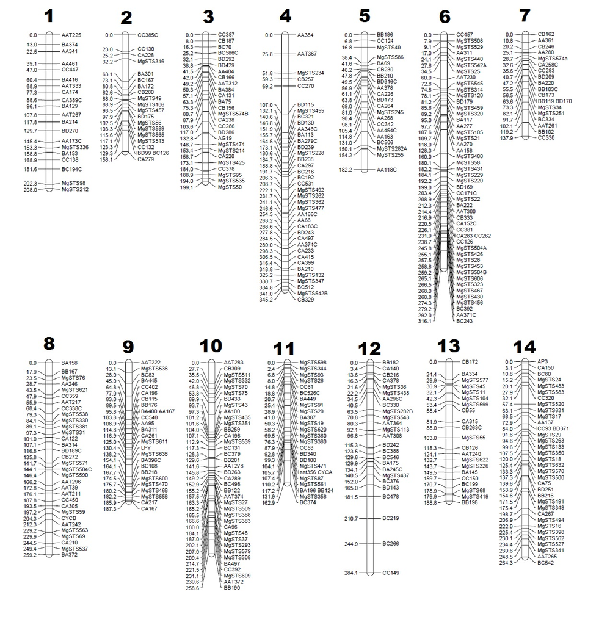

## 1.2 Entrada dos dados no R/qtl

De posse do mapa genético e do conjunto de dados completos do MIMULUS foi possível entrar com os dados no programa R/qtl da seguinte maneira:

- Mudar o diretório do R para a pasta onde foi salvo o arquivo do mapa e o arquivo completo do MIMULUS

```r
setwd("C:/Users/Felipe/Dropbox/Disciplinas/Biometria_de_marcadores_geneticos/aula_10")
```

- Requerer o “pacote” R/qtl

```r
library("qtl")
```

- Carregar os arquivos contendo o conjunto completo dos dados (**m_feb06.raw**) e o arquivo contendo o mapa genético (**mimulus_mapa_final.txt**):

$OBS_1$: O arquivo original do mimulus está salvo em **.raw** (contém dados genotípicos e fenotípicos)

$OBS_2$: Seguinto o tutorial do R/qtl foi possível identificar que o programa reconhece arquivos **.txt** exportados do OneMap. O mapa genético do conjunto de dados MIMULUS foi obtido pelo programa OneMap e exportado através da função **write.map(mapa, “mimulus_mapa_final”)**. A saída foi salva em um arquivo **.txt** contendo o mapa final do MIMULUS (arquivo **mimulus_mapa_final.txt**).

$OBS_3$: para abrir os arquivos no R/qtl, foi utilizado a função **read.cross** e o formato MapMaker (**“mm”**).

```r
dados_mimulus = read.cross("mm", file="m_feb06.raw", mapfile = "mimulus_mapa_final.txt")
```

```
##  --Read the following data:
##  Type of cross:          f2
##  Number of individuals:  287
##  Number of markers:      418
##  Number of phenotypes:   16
```

```
##  --Cross type: f2
```

- Como haviam marcadores sobrepostos uma mesma posição no cromossomo, foi utilizado a função **jittermap** (segundo o tutorial do R/qtl) para o ajuste.

```r
mimulus = jittermap(dados_mimulus)
```

- Após o carregamento, é possível observar um resumo dos dados do MIMULUS

```r
#Resumo dos dados
summary(mimulus)
```

```
##     F2 intercross
##
##     No. individuals:    287
##
##     No. phenotypes:     16
##     Percent phenotyped: 96.2 93.4 96.2 93 95.8 87.8 96.2 95.8 96.2 96.2
##                         90.2 96.2 95.8 96.2 95.8 96.2
##
##     No. chromosomes:    14
##         Autosomes:      1 2 3 4 5 6 7 8 9 10 11 12 13 14
##
##     Total markers:      377
##     No. markers:        20 20 26 38 21 49 19 32 26 38 26 25 21 16
##     Percent genotyped:  89.6
##     Genotypes (%):      AA:15.4  AB:24.3  BB:23.0  not BB:20.5  not AA:16.8
```

De acordo com o resumo dos dados, pode-se verificar que na população estudada (população $F_2$) existem 287 indivíduos, 377 marcadores (418 no total, no entanto o mapa final foi construido com 377 marcadores) e 16 características fenotípicas.

- Mapa genético (versão R/qtl)

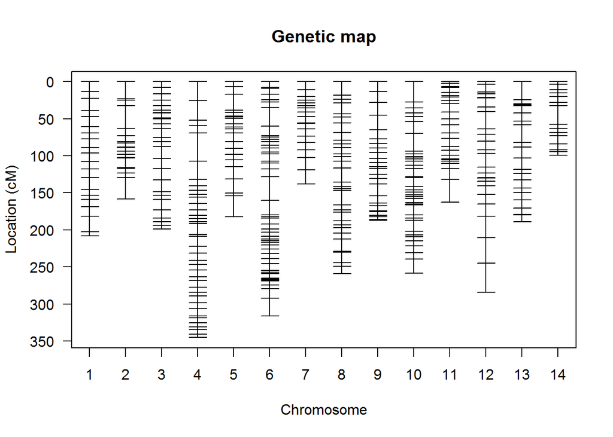

```r
#Mapa genético Mimulus
plot.map(mimulus)
```

- Para observar cada uma das características fenotípicas, foram plotados os seguintes gráficos:

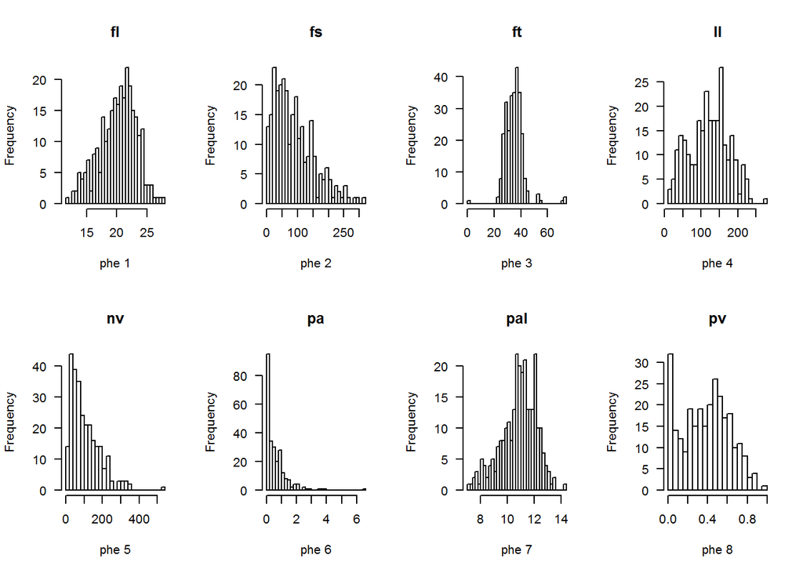

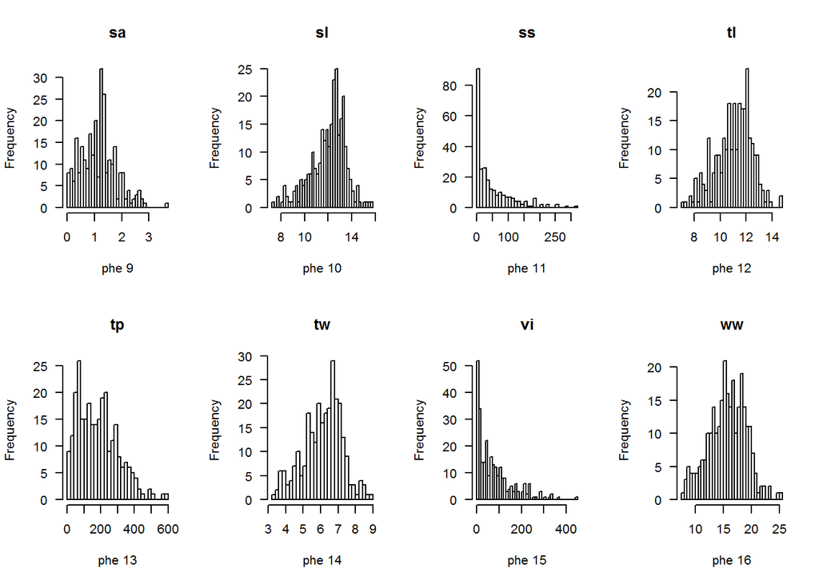

```r
par(mfrow=c(2,4))
for(i in 1:16)
  plot.pheno(mimulus, pheno.col=i)
```

- Iremos trabalhar com a característica fenotípica **pa** (phe 6)

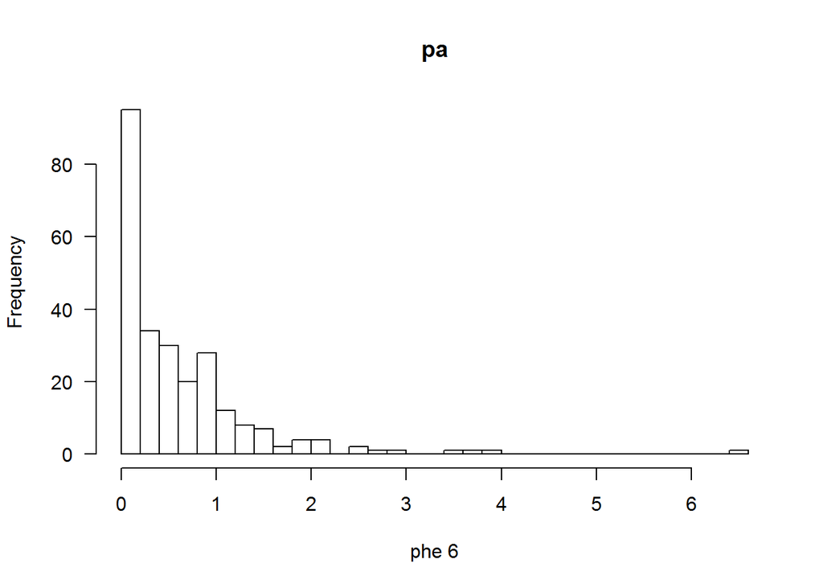

```r
plot.pheno(mimulus, pheno.col= 6)
```

## 1.3 Nível de significância (“Threshold”)

Primeiramente foi calculado o nível de significância (LOD) para declarar como significativo o efeito dos QTLs (“Threshold”).

Para isso, criou-se a distribuição de LODs sob $H_0$ utilizado os seguintes comandos:

$OBS_1$: foi utilizado a aproximação de Haley-Knott (“hk”) no cálculo das permutações;

$OBS_2$: foram realizadas 1000 permutações.

```r
#Significância - "uso de permutações"
mimulus_gp = calc.genoprob(mimulus, step = 1, error.prob=0.0001)
sig_perm = scanone(mimulus_gp, method = "hk", pheno.col=6, tol=1e-4, n.perm=1000)
```

```
## Doing permutation in batch mode ...
```

Foram obtidos os valores do threshold (LOD) para 5% e 1% de significância:

```r
summary(sig_perm, alpha=c(0.05, 0.01))
```

```
## LOD thresholds (1000 permutations)
##     lod
## 5% 3.96
## 1% 5.55
```

E o gráfico da distribuição da estastística (LOD) sob $H_0$:

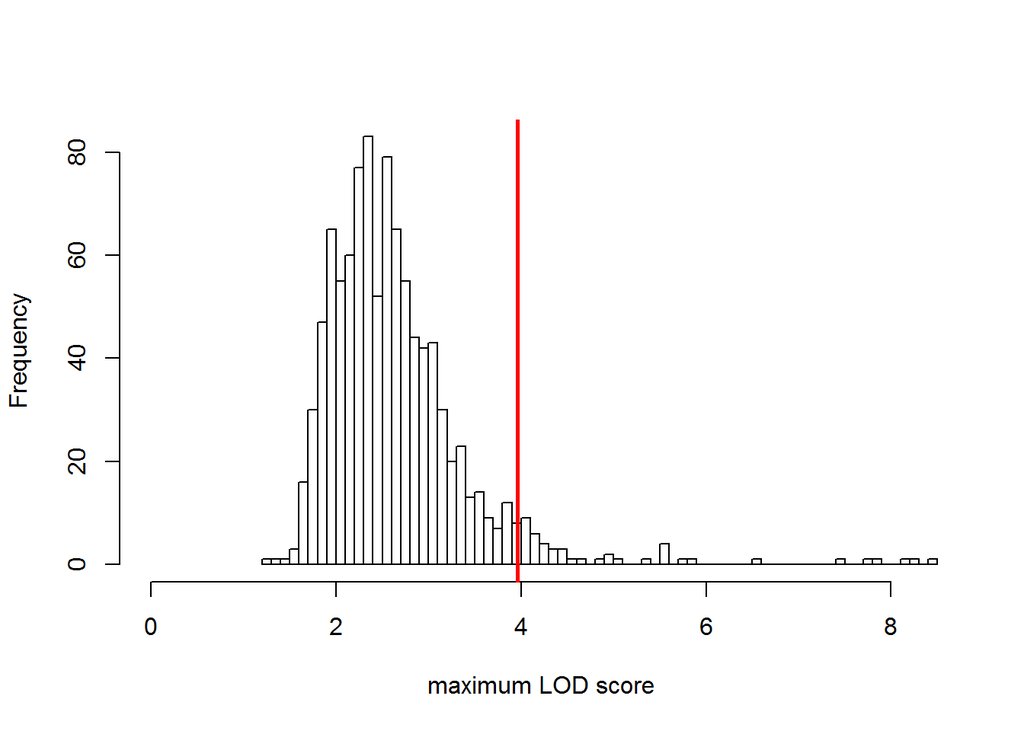

```r
plot(sig_perm)
abline(v=3.96, col="red", lwd=2.5)
```

## 1.4 Mapeamento por intervalo (IM)

O mapeamento por intervalo foi realizado utilizando os seguintes comandos:

$OBS_1$: foi utilizado o algorítmo **“EM”**

$OBS_2$: foi utilizado um **threshold de 3,96** (calculado por permutação).

```r
#IM (mapeamento intervalo - método "EM")
mimulus_gp = calc.genoprob(mimulus, step = 1, error.prob=0.0001)
mimulus_em = scanone(mimulus_gp, method = "em", pheno.col=6, tol=1e-6)
summary(mimulus_em)
```

```
##            chr   pos   lod
## AA173C       1 145.4 0.531
## CA279        2 158.1 0.401
## MgSTS425     3 173.1 0.662
## c4.loc178    4 178.0 0.973
## AA163        5 114.8 0.695
## c6.loc233    6 233.0 4.288
## MgSTS574a    7  28.7 1.626
## c8.loc105    8 105.0 1.429
## c9.loc149    9 149.0 1.919
## MgSTS27     10 163.3 1.563
## BA449       11  20.7 0.899
## BC219       12 210.7 1.327
## c13.loc176  13 176.0 1.901
## MgSTS263    14  94.6 1.962
```

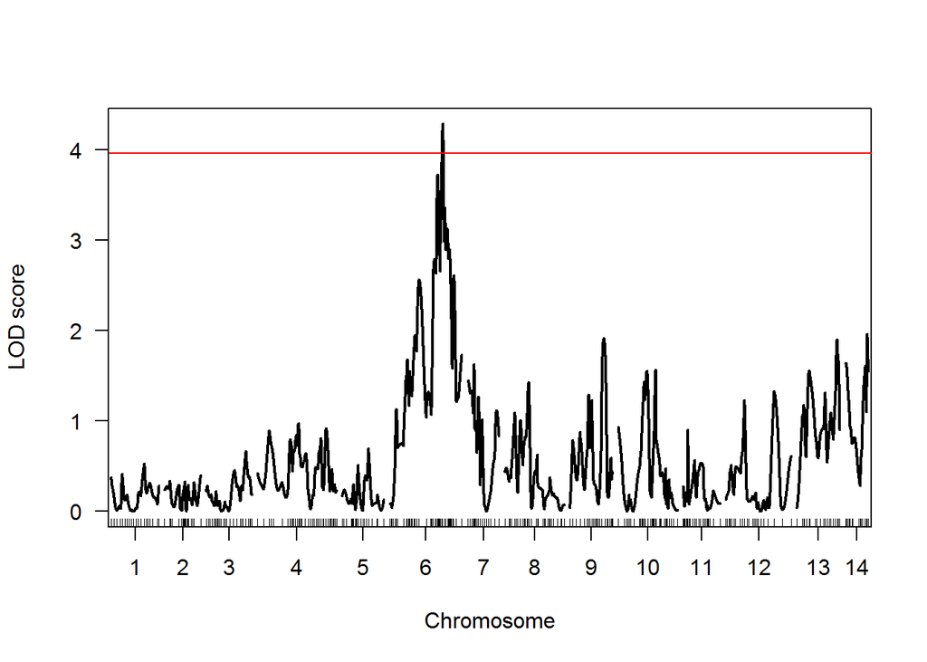

```r
plot(mimulus_em, ylab="LOD score")
abline(h = 3.96, col="red") #5% significância
```

De acordo com o gráfico é observado que, para a característica fenotípica **pa**, há evidências de um QTL no grupo de ligação 6 (cromossomo 6), acima do threshold (LOD = 3,96).

Pelos comando abaixo é possível observar em detalhes o grupo de ligação 6:

```r
#Cromossomo 6 somente
mimulus_em2 = scanone(mimulus_gp, method = "em", pheno.col=6, tol=1e-6, chr = c(6))
```

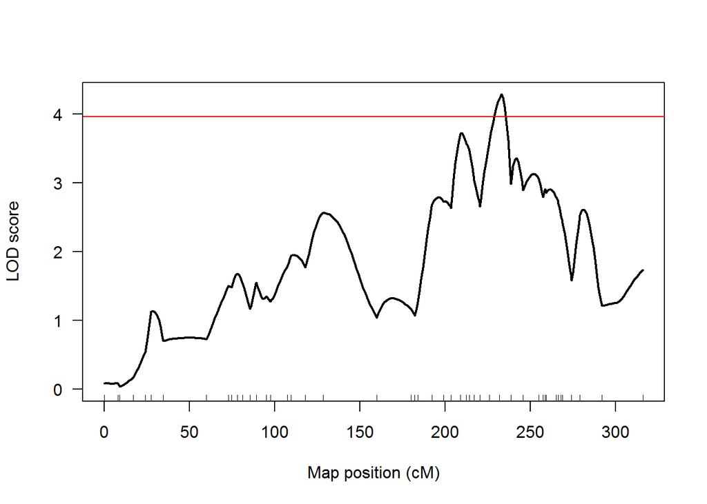

```r
plot(mimulus_em2, ylab="LOD score")
abline(h = 3.96, col="red") #5%
```

```r
summary(mimulus_em2)
```

```
##           chr pos  lod
## c6.loc233   6 233 4.29
```

O pico do gráfico evidencia um QTL na posição **233 cM**, acima do threshold (LOD = 3,96).

Para encontrar os efeitos do QTL em questão, foi utilizado os seguintes comandos:

```r
#Efeito do QTL
mimulus_qtl_3 = makeqtl(mimulus_gp, chr=c(6), pos=c(233), what="prob")
qtl_3 = fitqtl(mimulus_gp, qtl = mimulus_qtl_3,
               method="hk", pheno.col=6, get.ests=TRUE)
summary(qtl_3)
```

```
##
##      fitqtl summary
##
## Method: Haley-Knott regression
## Model:  normal phenotype
## Number of observations : 252
##
## Full model result
## ----------------------------------
## Model formula: y ~ Q1
##
##        df        SS        MS      LOD     %var Pvalue(Chi2)    Pvalue(F)
## Model   2  10.61799 5.3089962 4.122062 7.256128 7.549843e-05 8.452985e-05
## Error 249 135.71338 0.5450337
## Total 251 146.33138
##
##
## Estimated effects:
## -----------------
##                  est         SE      t
## Intercept  6.243e-01  4.690e-02 13.313
## 6@233.0a  -3.057e-01  7.008e-02 -4.362
## 6@233.0d  -7.777e-05  9.934e-02 -0.001
```

```r
n=282
LOD1=4.122062
r2=1-10^(((-2)/n)*LOD1)
r2 #Valor do Rsquared
```

```
## [1] 0.06509923
```

### 1.4.1 Resultado do IM

O resultado do mapeamento por intervalo (IM) foi resumido na Tabela abaixo (contendo o nome do QTL, o cromossomo que o contêm, a posição no cromossomo, o valor do intercepto da regressão, os valores dos efeito do QTL (aditivo e de dominância), o LOD e o $R^2$:

[output not shown]

E também na Figura:

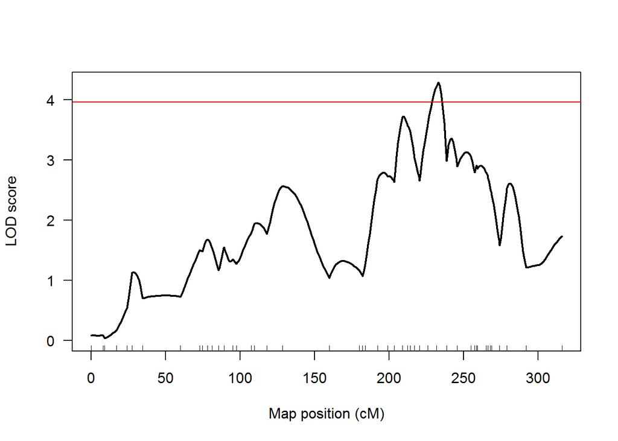

```r
plot(mimulus_em, ylab="LOD score",chr=c(6))
abline(h = 3.96, col="red") #5%
```

## 1.5 Mapeamento por intervalo composto (CIM)

Primeiramente foi realizado o teste de **stepwise (regressão múltipla)** para escolha do modelo que melhor se ajusta aos dados, ou seja, para verificar o número de cofatores que irão entrar no modelo de mapeamento por intervalo composto (CIM).

$OBS_1$: Testou-se um máximo de 5 QTLs que poderiam entrar no modelo como cofatores (testou-se 5 cofatores a princípio).

```r
#Step Wise - escolha do modelo
mimulus_gp = calc.genoprob(mimulus, step = 1, error.prob=0.0001)
mimulus_stepwise = stepwiseqtl(mimulus_gp, chr = c(1:14), pheno.col=6,
                                max.qtl = 5, method = "hk")
```

```
##  -Initial scan
## initial lod:  4.244194
## ** new best ** (pLOD increased by 0.7242)
##     no.qtl =  1   pLOD = 0.7241939   formula: y ~ Q1
##  -Step 1
##  ---Scanning for additive qtl
##         plod = -0.5819009
##  ---Scanning for QTL interacting with Q1
##         plod = 0.4357183
##  ---Refining positions
##  ---  Moved a bit
##     no.qtl =  2   pLOD = 0.6418344   formula: y ~ Q1 + Q2 + Q1:Q2
##  -Step 2
##  ---Scanning for additive qtl
##         plod = 0.001723726
##  ---Scanning for QTL interacting with Q1
##         plod = -2.271356
##  ---Scanning for QTL interacting with Q2
##         plod = -2.364854
##  ---Look for additional interactions
##  ---Refining positions
##  ---  Moved a bit
##     no.qtl =  3   pLOD = 0.215045   formula: y ~ Q1 + Q2 + Q1:Q2 + Q3
##  -Step 3
##  ---Scanning for additive qtl
##         plod = -1.657973
##  ---Scanning for QTL interacting with Q1
##         plod = -3.373935
##  ---Scanning for QTL interacting with Q2
##         plod = -2.307195
##  ---Scanning for QTL interacting with Q3
##         plod = -0.7009392
##  ---Look for additional interactions
##         plod = -2.050625
##  ---Refining positions
##  ---  Moved a bit
##     no.qtl =  4   pLOD = -0.07738179   formula: y ~ Q1 + Q2 + Q1:Q2 + Q3 + Q4 + Q3:Q4
##  -Step 4
##  ---Scanning for additive qtl
##         plod = -0.9362347
```

[output cut: 16 more lines]

```
##  ---Refining positions
##  ---  Moved a bit
##  ---Dropping Q4
##     no.qtl =  3   pLOD = 0.1254446   formula: y ~ Q1 + Q2 + Q3 + Q1:Q2
##  ---Refining positions
##  ---  Moved a bit
##  ---Dropping Q3
##     no.qtl =  2   pLOD = 0.5161596   formula: y ~ Q1 + Q2 + Q1:Q2
##  ---Refining positions
##  ---  Moved a bit
##  ---Dropping Q2
##     no.qtl =  1   pLOD = 0.6791916   formula: y ~ Q1
##  ---Refining positions
##  ---  Moved a bit
##  ---One last pass through refineqtl
```

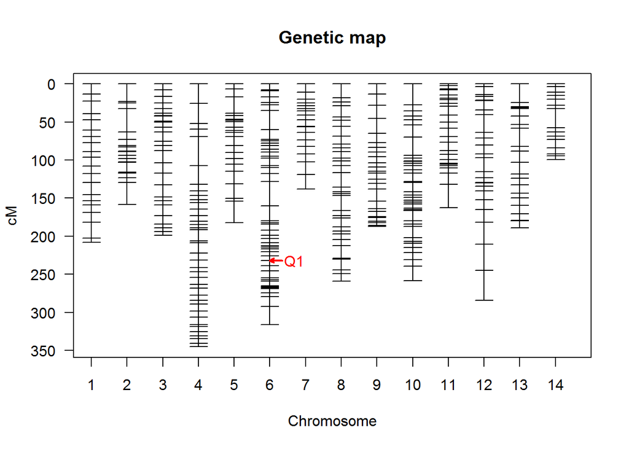

```r
plot(mimulus_stepwise, ylab="cM")
```

```r
summary(mimulus_stepwise)
```

```
##   QTL object containing genotype probabilities.
##
##       name chr    pos n.gen
## Q1 6@231.9   6 231.85     3
##
##   Formula: y ~ Q1
##
##   pLOD:  0.724
```

Pelo método de stepwise, é definido que **Y = Q1** , ou seja, apenas 1 cofator entra no modelo de mapeamento por intervalo composto.

Dessa forma o mapeamento por intervalo composto pode ser realizado de acordo com os comando abaixo:

$OBS_1$: foi utilizado o algoritmo **“EM”**;

$OBS_2$: foi utilizado **1 cofator** (pela regressão múltipla de stepwise foi identificado um QTL de efeito maior sobre a característica em questão);

$OBS_3$: foi utilizado uma **window size = 10 cM**;

$OBS_4$: foi utilizado um **threshold = 3,96** (cálculo por permutação)

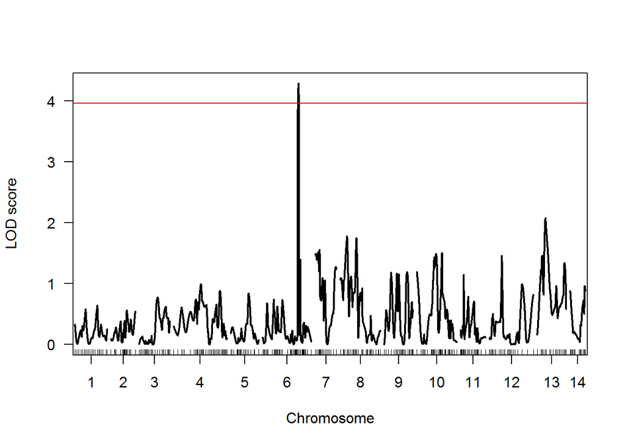

```r
# Mapeamento - intervalo composto (CIM)
mimulus_cim = cim(mimulus_gp, pheno.col=6, n.marcovar=1,
                  window=10, method = "em", error.prob=0.0001, map.function = "kosambi")
plot(mimulus_cim, ylab="LOD score")

abline(h = 3.96, col="red") #5%
```

```r
summary(mimulus_cim)
```

```
##           chr   pos   lod
## AA173C      1 145.4 0.639
## MgSTS589    2 103.3 0.560
## c3.loc120   3 120.0 0.776
## c4.loc177   4 177.0 0.995
## AA163       5 114.8 0.843
## c6.loc233   6 233.0 4.288
## c7.loc28    7  28.0 1.556
## MgSTS621    8  43.5 1.778
## c9.loc148   9 148.0 1.193
## MgSTS27    10 163.3 1.502
## BA449      11  20.7 1.148
## AAT364     12  80.3 1.458
## MgSTS599   13  53.4 2.074
## MgSTS263   14  94.6 0.967
```

Pelos comandos abaixo é possível observar em detalhes o grupo de ligação 6:

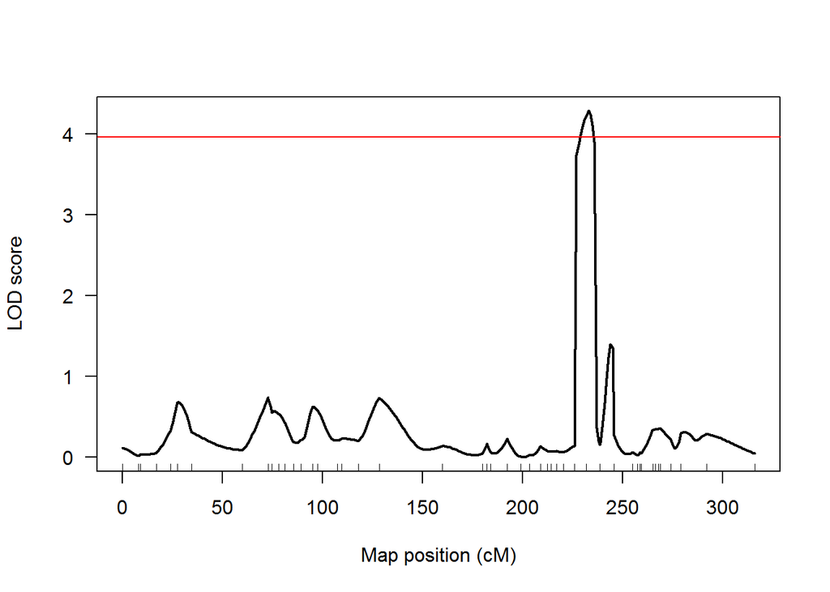

```r
plot(mimulus_cim, ylab="LOD score", chr=c(6))
abline(h = 3.96, col="red") #5%
```

Para encontrar os efeitos do QTL em questão, foi utilizado os seguintes comandos:

```r
#Efeito do QTL
mimulus_qtl_cim = makeqtl(mimulus_gp, chr=c(6), pos=c(231), what="prob")
qtl_cim_6 = fitqtl(mimulus_gp, qtl = mimulus_qtl_cim,
                  method="hk", pheno.col=6, get.ests=TRUE)
summary(qtl_cim_6)
```

```
##
##      fitqtl summary
##
## Method: Haley-Knott regression
## Model:  normal phenotype
## Number of observations : 252
##
## Full model result
## ----------------------------------
## Model formula: y ~ Q1
##
##        df        SS        MS      LOD     %var Pvalue(Chi2)    Pvalue(F)
## Model   2  10.91116 5.4555806 4.240399 7.456474 5.749118e-05 6.457764e-05
## Error 249 135.42021 0.5438563
## Total 251 146.33138
##
##
## Estimated effects:
## -----------------
##                  est         SE      t
## Intercept  6.238e-01  4.681e-02 13.326
## 6@231.0a  -3.080e-01  6.935e-02 -4.441
## 6@231.0d   3.555e-05  9.779e-02  0.000
```

```r
n=282
LOD1=4.240399
r21=1-10^(((-2)/n)*LOD1)
r21
```

```
## [1] 0.06690417
```

### 1.5.1 Resultado do CIM

O resultado do mapeamento por intervalo composto (CIM) foi resumido na Tabela abaixo (contendo o nome do QTL, o cromossomo que o contêm, a posição no cromossomo, o valor do intercepto da regressão, os valores dos efeito do QTL (aditivo e de dominância), o LOD e o $R^2$:

[output not shown]

E também no gráfico:

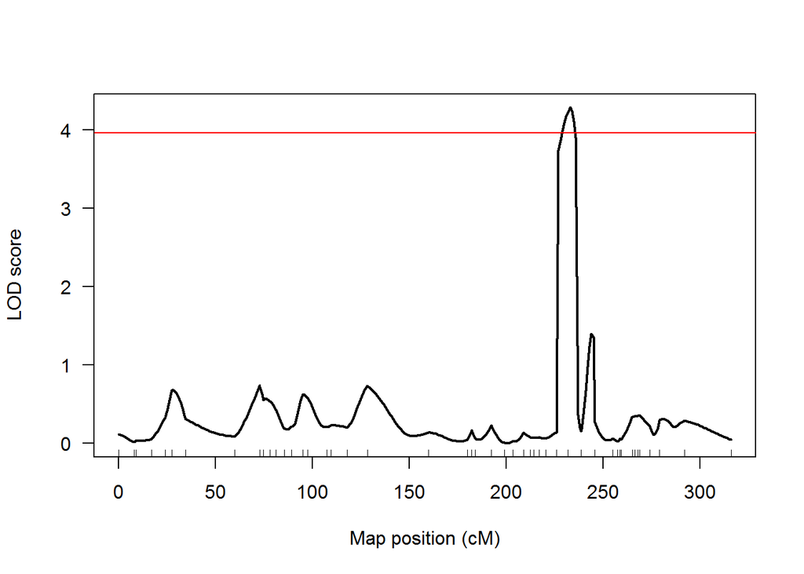

```r
plot(mimulus_cim, ylab="LOD score",chr=c(6))
abline(h = 3.96, col="red") #5%
```

## 1.6 Comparação dos 2 métodos (IM vs CIM)

Os dois métodos (IM e CIM) foram comparados pela seguinte análise gráfica:

- O gráfico em azul representa o resultado do IM para a característica **pa**
- O gráfico em vermelho representa o CIM para a característica **pa**

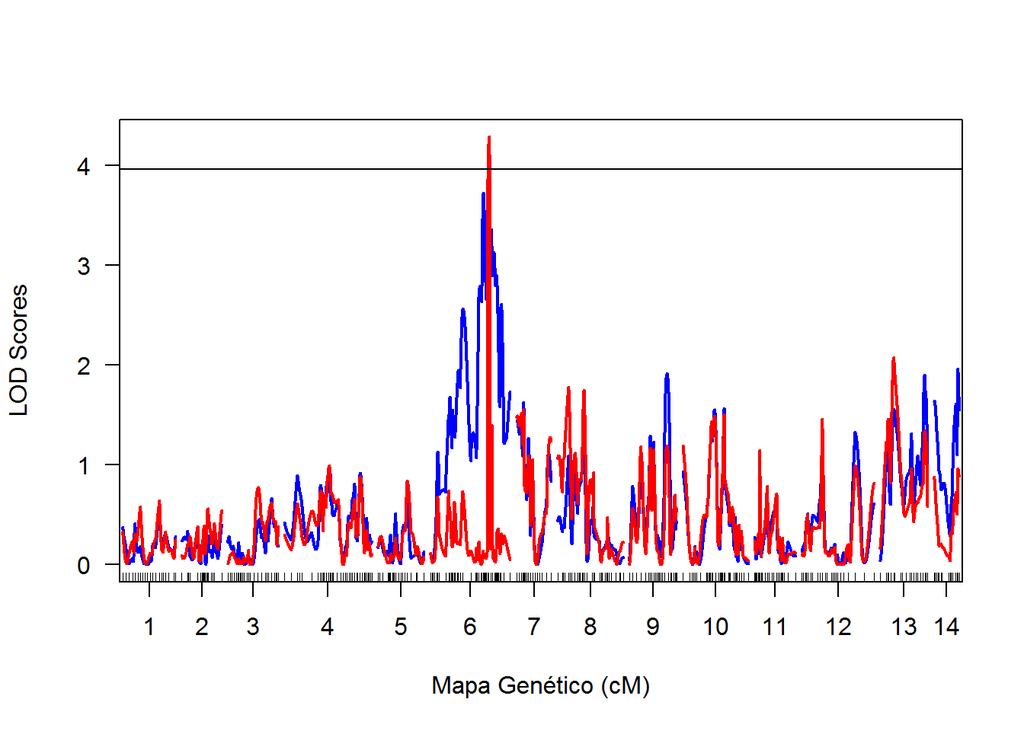

```r
plot(mimulus_em,mimulus_cim, col=c("blue","red"), ylab="LOD Scores", xlab="Mapa Genético (cM)")
abline(h = 3.96) #5%
```

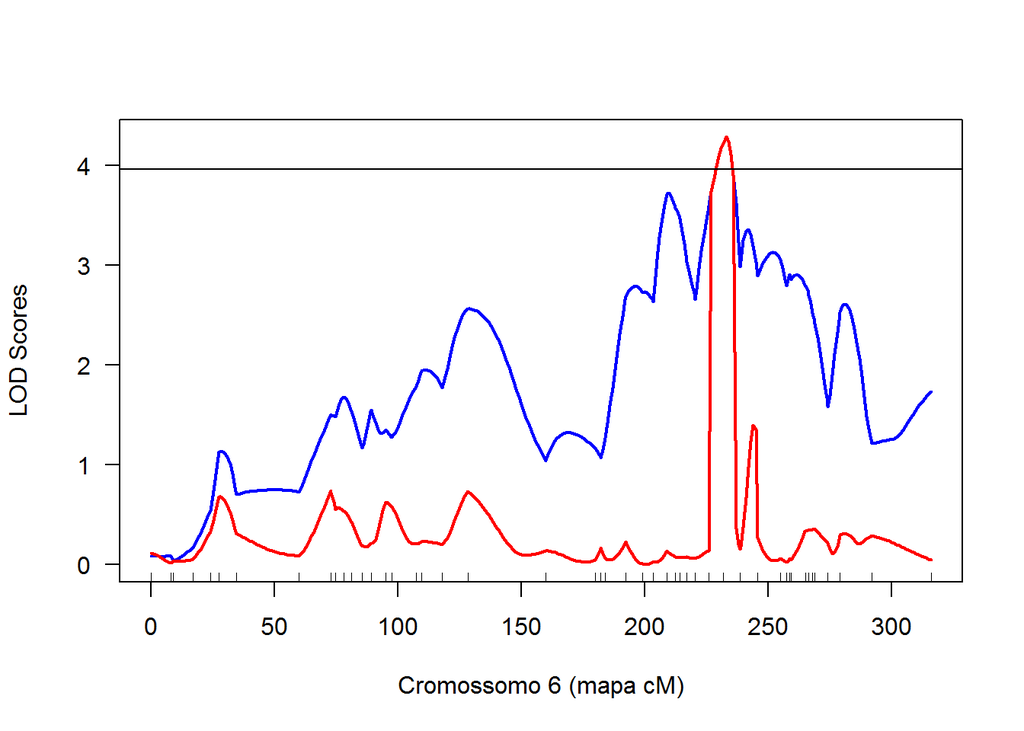

```r
plot(mimulus_em,mimulus_cim, col=c("blue","red"),
     chr=c(6), ylab="LOD Scores", xlab="Cromossomo 6 (mapa cM)")
abline(h = 3.96) #5%
```

Pelos dois métodos foi encontrado um QTL no cromossomo 6 relacionado com a característica fenotípica **pa**. Observando os resultados gráficos dos dois métodos é evidente a maior precisão do CIM (pico do gráfico com maior precisão da posição do QTL), pois o uso do cofator nesse método permitiu explicar parte da variação genética e minimizar erros, como o próprio efeito do QTL na região adjacente.